# Patrones de las aplicaciones exitosas en Google Play Store

Enrique Esis

15 de junio de 2024

# 1 Definición del problema/objetivo de investigación.

Desarrollar un análisis integral del conjunto de datos de aplicaciones de la Play Store de Google para entender su estructura, limpiar y preparar los datos, realizar un análisis exploratorio exhaustivo y construir modelos predictivos que permitan predecir la calificación de las aplicaciones, utilizando técnicas de Random Forest y árboles de decisión.

## 1.1 Objetivos Específicos

**1)** Obtener un resumen detallado y rápido del conjunto de datos para entender su estructura y contenido.

**2)** Seleccionar las variables relevantes para el análisis y eliminar las irrelevantes.

**3)** Limpiar el conjunto de datos eliminando filas con valores nulos para asegurar la integridad del análisis.

**4)** Realizar análisis visuales y estadísticos para entender mejor las distribuciones y relaciones entre variables.

**5)** Desarrollar modelos predictivos utilizando Random Forest y árboles de decisión para predecir la Calificación de las aplicaciones.

# 2 Introducción

En el acelerado universo de las aplicaciones móviles, la Google Play Store representa un inmenso repositorio que aloja millones de aplicaciones, abarcando desde juegos y herramientas de productividad hasta aplicaciones de estilo de vida y educación. Este proyecto se centra en analizar un conjunto de datos de aplicaciones de la Google Play Store para extraer información valiosa sobre las tendencias predominantes y los factores determinantes del éxito en este dinámico mercado. El conjunto de datos seleccionado contiene información detallada sobre diversas métricas de las aplicaciones, tales como el nombre, la categoría, la calificación, el número de instalaciones, y el precio, entre otros.

## 2.1 Descripción de las variables de interes:

- **Categoría**: Esta variable clasifica la aplicación móvil en una categoría específica, como redes sociales, juegos, productividad, etc.
- **Clasificación.de.Contenido**: Indica la calificación o etiqueta de contenido asignada a la aplicación, como “Para todos”, “Solo para adultos”, “Adolescentes”, etc.
- **Calificación**: Esta variable indica la puntuación promedio otorgada por los usuarios a la aplicación. Por lo general, se basa en una escala de 1 a 5 estrellas, donde 5 representa la mejor calificación.
- **Número.de.Calificaciones**: Indica la cantidad total de calificaciones que ha recibido la aplicación. Cuanto mayor sea este número, más representativa será la calificación promedio.
- **Instalaciones.Máximas**: Es el número total de veces que la aplicación ha sido instalada en dispositivos móviles.
- **Admite.Anuncios**: Esta variable es binaria y especifica si la aplicación admite anuncios publicitarios dentro de su interfaz. Puede ser “Sí” o “No”.
- **Compras.dentro.de.la.Aplicación**: Esta variable es binaria y especifica si la aplicación ofrece compras dentro de la aplicación. Puede ser “Sí” o “No”.
- **Precio**: Indica el costo de la aplicación para el usuario. Puede ser un valor numérico que representa el precio en la moneda local, o “Gratis” si la aplicación no tiene costo.

## 2.2 Funciones a programar:

**1)** Función para generar boxblot multivariables

# 3 Preprocesamiento de Datos

## 3.1 Carga de paquetes

```r
library(tidyverse)      # Carga el paquete para manipulación de datos
library(readxl)         # Carga el paquete para leer archivos Excel
library(ggplot2)        # Carga el paquete para gráficos
library(dplyr)          # Carga el paquete para manipulación de datos
library(corrplot)       # Carga el paquete para visualizar la matriz de correlación
library(visdat)         # Carga el paquete para visualizar datos faltantes
library(readr)          # Carga el paquete para leer archivos csv
library(skimr)          # Carga el paquete para resúmenes estadísticos rápidos
library(data.tree)      # Carga el paquete para manipulación de árboles de datos
library(DiagrammeR)     # Carga el paquete para crear diagramas de redes
library(tinytex)        # Carga el paquete para compilar documentos LaTeX
library(RColorBrewer)   # Carga el paquete para paletas de colores para gráficos
library(randomForest)   # Carga el paquete para algoritmos de bosques aleatorios
```

## 3.2 Carga de datos

Carga el archivo desde ubicación de github

```r
#enlace <-'https://raw.githubusercontent.com/EnriqueEsis/EESIS/main/Google-Playstore_T_R.csv'
#df <- read.csv(enlace, sep = ",")

# Ruta de ubicación de windows
ruta_archivo <-'C:\\Users\\EEsis\\Downloads\\Datasets\\Google-Playstore_T_R.csv'

# Cargar el archivo CSV desde ubicación de windows
df <- read.csv(ruta_archivo, fileEncoding = "Latin1")
```

## 3.3 Identificar los tipos de variables

Mostrar resumen rápido y completo del conjunto de datos

```r
skim(df)
```

Data summary

| Name | df |
| --- | --- |
| Number of rows | 31451 |
| Number of columns | 23 |
| _______________________ |  |
| Column type frequency: |  |
| character | 18 |
| numeric | 5 |
| ________________________ |  |
| Group variables | None |

**Variable type: character**

| skim_variable | n_missing | complete_rate | min | max | empty | n_unique | whitespace |
| --- | --- | --- | --- | --- | --- | --- | --- |
| ID.de.la.Aplicación | 94 | 1 | 5 | 139 | 0 | 31357 | 0 |
| Categoría | 94 | 1 | 5 | 17 | 0 | 10 | 0 |
| Instalaciones | 94 | 1 | 8 | 8 | 0 | 2 | 0 |
| Gratis | 94 | 1 | 4 | 5 | 0 | 2 | 0 |
| Moneda | 94 | 1 | 0 | 3 | 1 | 3 | 0 |
| Tamaño | 94 | 1 | 3 | 18 | 0 | 839 | 0 |
| Android.Mínimo | 94 | 1 | 0 | 18 | 34 | 40 | 0 |
| ID.del.Desarrollador | 94 | 1 | 2 | 106 | 0 | 21229 | 0 |
| Sitio.Web.del.Desarrollador | 94 | 1 | 0 | 223 | 8261 | 17023 | 0 |
| Correo.Electrónico.del.Desarrollador | 94 | 1 | 0 | 111 | 4 | 22092 | 0 |
| Fecha.de.Lanzamiento | 94 | 1 | 0 | 12 | 732 | 3913 | 0 |
| Última.Actualización | 94 | 1 | 12 | 12 | 0 | 2867 | 0 |
| Clasificación.de.Contenido | 94 | 1 | 4 | 15 | 0 | 6 | 0 |
| Política.de.Privacidad | 94 | 1 | 0 | 233 | 4066 | 20446 | 0 |
| Admite.Anuncios | 94 | 1 | 4 | 5 | 0 | 2 | 0 |
| Compras.dentro.de.la.Aplicación | 94 | 1 | 4 | 5 | 0 | 2 | 0 |
| Elección.de.los.Editores | 94 | 1 | 4 | 5 | 0 | 2 | 0 |
| Tiempo.de.Extracción | 94 | 1 | 19 | 19 | 0 | 24718 | 0 |

**Variable type: numeric**

| skim_variable | n_missing | complete_rate | mean | sd | p0 | p25 | p50 | p75 | p100 | hist |
| --- | --- | --- | --- | --- | --- | --- | --- | --- | --- | --- |
| Calificación | 94 | 1 | 3.97 | 0.62 | 1.1 | 3.7 | 4.1 | 4.4 | 5.00 | ▁▁▂▇▇ |
| Número.de.Calificaciones | 94 | 1 | 1133.70 | 561.65 | 400.0 | 656.0 | 1004.0 | 1518.0 | 2500.00 | ▇▆▃▂▂ |
| Instalaciones.Mínimas | 94 | 1 | 126010.14 | 98629.81 | 100000.0 | 100000.0 | 100000.0 | 100000.0 | 500000.00 | ▇▁▁▁▁ |
| Instalaciones.Máximas | 94 | 1 | 245263.33 | 129250.87 | 105482.0 | 145735.0 | 203759.0 | 307287.0 | 676507.00 | ▇▃▂▁▁ |
| Precio | 94 | 1 | 0.01 | 0.24 | 0.0 | 0.0 | 0.0 | 0.0 | 19.99 | ▇▁▁▁▁ |

```r
head(df)
```

|  | ID.de.la.Aplicación | Categoría | Calificación | Número.de.Calificaciones | Instalaciones | Instalaciones.Mínimas | Instalaciones.Máximas | Gratis | Precio | Moneda | Tamaño | Android.Mínimo | ID.del.Desarrollador | Sitio.Web.del.Desarrollador | Correo.Electrónico.del.Desarrollador | Fecha.de.Lanzamiento | Última.Actualización | Clasificación.de.Contenido | Política.de.Privacidad | Admite.Anuncios | Compras.dentro.de.la.Aplicación | Elección.de.los.Editores | Tiempo.de.Extracción |
| --- | --- | --- | --- | --- | --- | --- | --- | --- | --- | --- | --- | --- | --- | --- | --- | --- | --- | --- | --- | --- | --- | --- | --- |
| 1 | com.bisgumah.barbie | Entertainment | 3.8 | 736 | 500,000+ | 5e+05 | 646456 | True | 0 | USD | 20M | 5.0 and up | bisgumah | https://appsabsadstxt.blogspot.com/ | bisgumah418@gmail.com | Apr 21, 2019 | Nov 13, 2020 | Everyone | https://docs.google.com/document/d/1kUDGpRA8fFBpy6x_L3tuC-C0po_ONPcSu1qRKVv3gNg/edit?usp=sharing | True | False | False | 2021-06-15 20:19:36 |
| 2 | com.impark.isemdijital | Education | 2.4 | 853 | 100,000+ | 1e+05 | 119488 | True | 0 | USD | Varies with device | 4.1 and up | Ä°MPARK | http://www.impark.com.tr | yonetim@impark.com.tr | Mar 15, 2019 | Nov 02, 2020 | Everyone | http://impark.com.tr/gizlilik_sozlesmesi.pdf | False | False | False | 2021-06-15 20:19:48 |
| 3 | com.qamar.ide.web | Productivity | 4.1 | 1476 | 100,000+ | 1e+05 | 192935 | True | 0 | USD | 6.0M | 4.1 and up | Alif software |  | alifsoftware6@gmail.com | Sep 7, 2018 | Jun 05, 2021 | Everyone |  | False | True | False | 2021-06-15 20:19:54 |
| 4 | fi.dna.omadna | Tools | 3.9 | 440 | 100,000+ | 1e+05 | 174403 | True | 0 | USD | 60M | 6.0 and up | DNA oyj | https://www.dna.fi | app.development@dna.fi | May 23, 2019 | May 27, 2021 | Everyone | https://corporate.dna.fi/tietosuoja | True | False | False | 2021-06-15 20:20:10 |
| 5 | com.bilinguae.deutsch.vokabular | Education | 4.7 | 520 | 100,000+ | 1e+05 | 130045 | True | 0 | USD | 6.2M | 5.1 and up | AltairApps | https://www.bilinguae.com | info@bilinguae.com | May 16, 2017 | Jun 14, 2021 | Everyone | https://www.bilinguae.com/privacy-policy | True | True | False | 2021-06-15 20:20:16 |
| 6 | com.digital.bangla.sokol_duyar_fojilot_o_amol | Books & Reference | 4.7 | 570 | 100,000+ | 1e+05 | 172665 | True | 0 | USD | 3.5M | 4.1 and up | BD Apps Station |  | shahenmustakim008@gmail.com | Feb 20, 2019 | Mar 21, 2020 | Everyone | https://appsstationbd.blogspot.com/p/privacy-policy.html | True | False | False | 2021-06-15 20:20:17 |

## 3.4 Selección y eliminación de variables

Se seleccionan las variables cuantitativas, cualitativas y se procede a eliminar el resto de las variables:

```r
# Nombre de las columnas que deseas conservar
columnas_a_conservar <- c("Admite.Anuncios",
                          "Calificación",
                          "Categoría",
                          "Precio",
                          "Clasificación.de.Contenido",
                          "Instalaciones.Máximas",
                          "Compras.dentro.de.la.Aplicación",
                          "Número.de.Calificaciones")

# Seleccionar solo las columnas especificadas
df <- df[, columnas_a_conservar]

view(df)
```

## 3.5 Eliminar filas con valores nulos y NA

```r
# Eliminar filas con NA en las columnas "Calificación"
df <- df[!is.na(df$Calificación), ]

# Eliminar filas con valores NA
df <- na.omit(df)
```

## 3.6 Verificar los cambios efectuados

Mostrar resumen rápido y completo del conjunto de datos para verificar los cambios realizados

```r
#df <- iris # Para comprobar los gráficos con otro dataset

skim(df)
```

Data summary

| Name | df |
| --- | --- |
| Number of rows | 31357 |
| Number of columns | 8 |
| _______________________ |  |
| Column type frequency: |  |
| character | 4 |
| numeric | 4 |
| ________________________ |  |
| Group variables | None |

**Variable type: character**

| skim_variable | n_missing | complete_rate | min | max | empty | n_unique | whitespace |
| --- | --- | --- | --- | --- | --- | --- | --- |
| Admite.Anuncios | 0 | 1 | 4 | 5 | 0 | 2 | 0 |
| Categoría | 0 | 1 | 5 | 17 | 0 | 10 | 0 |
| Clasificación.de.Contenido | 0 | 1 | 4 | 15 | 0 | 6 | 0 |
| Compras.dentro.de.la.Aplicación | 0 | 1 | 4 | 5 | 0 | 2 | 0 |

**Variable type: numeric**

| skim_variable | n_missing | complete_rate | mean | sd | p0 | p25 | p50 | p75 | p100 | hist |
| --- | --- | --- | --- | --- | --- | --- | --- | --- | --- | --- |
| Calificación | 0 | 1 | 3.97 | 0.62 | 1.1 | 3.7 | 4.1 | 4.4 | 5.00 | ▁▁▂▇▇ |
| Precio | 0 | 1 | 0.01 | 0.24 | 0.0 | 0.0 | 0.0 | 0.0 | 19.99 | ▇▁▁▁▁ |
| Instalaciones.Máximas | 0 | 1 | 245263.33 | 129250.87 | 105482.0 | 145735.0 | 203759.0 | 307287.0 | 676507.00 | ▇▃▂▁▁ |
| Número.de.Calificaciones | 0 | 1 | 1133.70 | 561.65 | 400.0 | 656.0 | 1004.0 | 1518.0 | 2500.00 | ▇▆▃▂▂ |

```r
head(df)
```

|  | Admite.Anuncios | Calificación | Categoría | Precio | Clasificación.de.Contenido | Instalaciones.Máximas | Compras.dentro.de.la.Aplicación | Número.de.Calificaciones |
| --- | --- | --- | --- | --- | --- | --- | --- | --- |
| 1 | True | 3.8 | Entertainment | 0 | Everyone | 646456 | False | 736 |
| 2 | False | 2.4 | Education | 0 | Everyone | 119488 | False | 853 |
| 3 | False | 4.1 | Productivity | 0 | Everyone | 192935 | True | 1476 |
| 4 | True | 3.9 | Tools | 0 | Everyone | 174403 | False | 440 |
| 5 | True | 4.7 | Education | 0 | Everyone | 130045 | True | 520 |
| 6 | True | 4.7 | Books & Reference | 0 | Everyone | 172665 | False | 570 |

# 4 Análisis Exploratorio de Datos

## 4.1 Graficos variables cuantitativas (BOXPLOT)

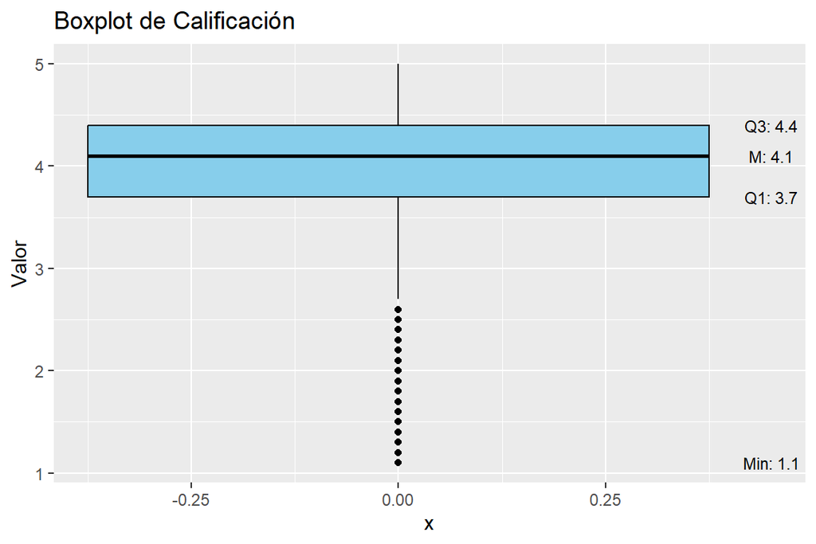

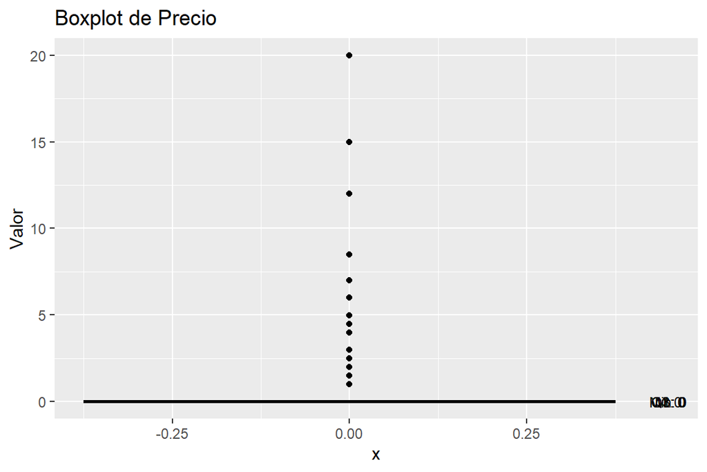

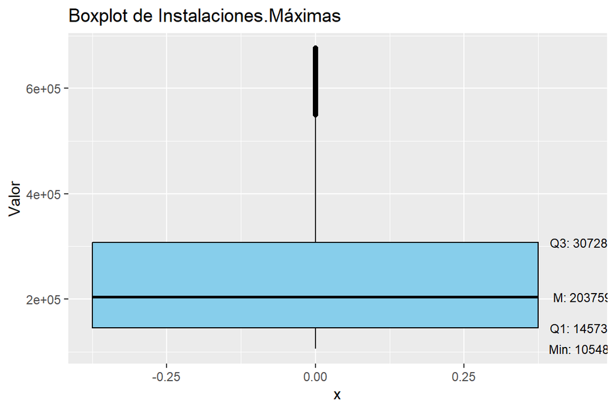

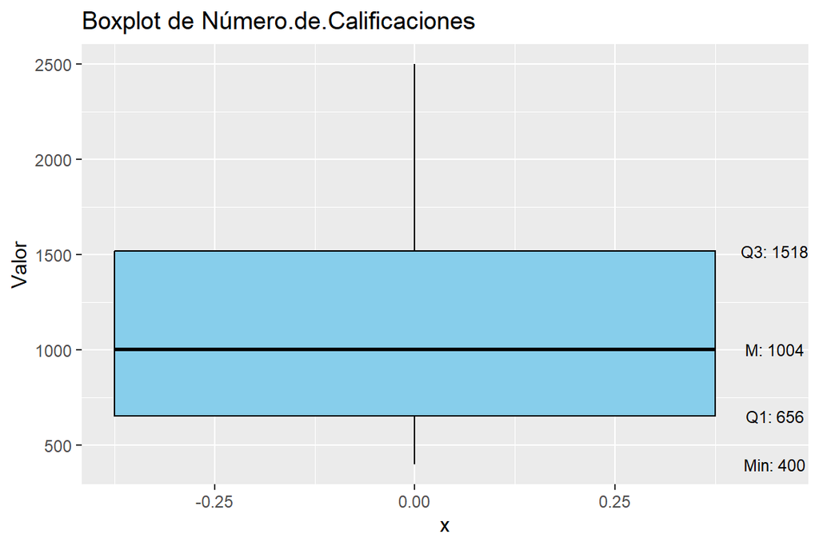

```r
numeric_df <- dplyr::select_if(df, is.numeric)

for (columna in names(numeric_df)) {

  # Calcular los valores estadísticos
  mediana <- median(numeric_df[[columna]])
  q1 <- quantile(numeric_df[[columna]], 0.25, na.rm = TRUE)
  q3 <- quantile(numeric_df[[columna]], 0.75, na.rm = TRUE)
  min_val <- min(numeric_df[[columna]])
  max_val <- max(numeric_df[[columna]])

  # Boxplot con etiquetas numéricas usando annotate
  boxplot <- ggplot(numeric_df, aes(y = !!sym(columna))) +
    geom_boxplot(fill = "skyblue", color = "black") +
    annotate("text", x =0.45, y = mediana, label = paste("M:", round(mediana, 2)), color = "black", size = 3) +
    annotate("text", x = 0.45, y = q1, label = paste("Q1:", round(q1, 2)), color = "black", size = 3) +
    annotate("text", x = 0.45, y = q3, label = paste("Q3:", round(q3, 2)), color = "black", size = 3) +
    annotate("text", x = 0.45, y = min_val, label = paste("Min:", round(min_val, 2)), color = "black", size = 3) +
    labs(title = paste("Boxplot de", columna), y = "Valor")

  # Mostrar el gráfico
  print(boxplot)

}
```

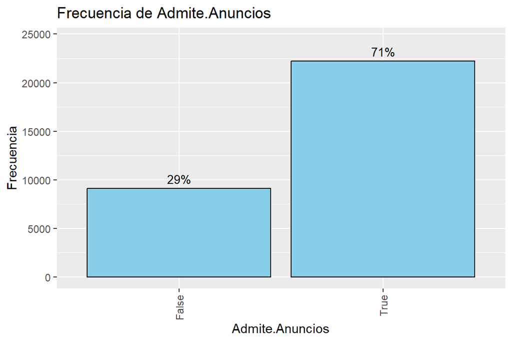

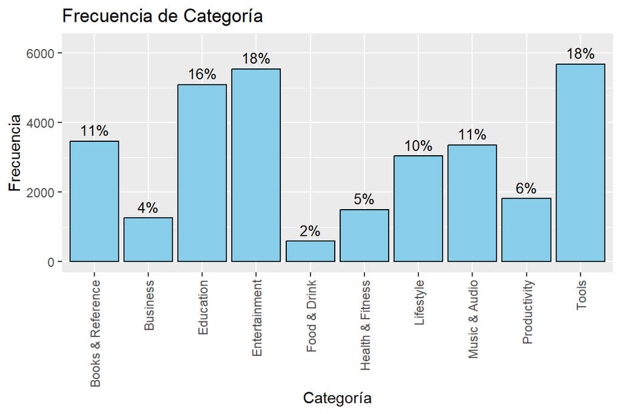

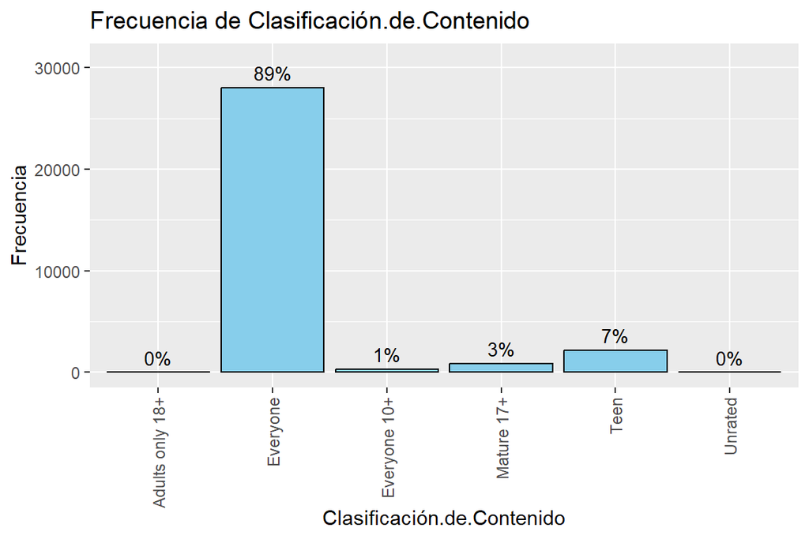

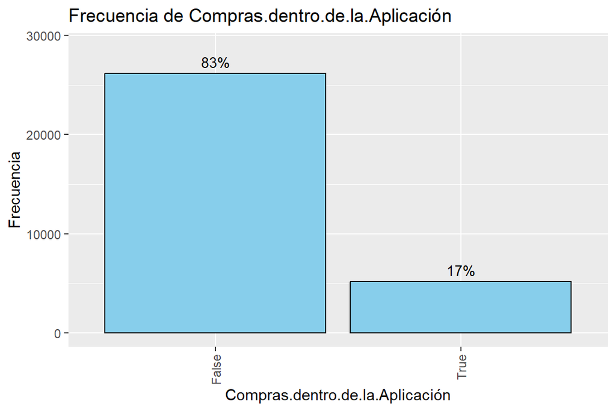

```r
# Seleccionar solo las columnas categóricas
columnas_chr <- names(df)[sapply(df, is.character)]
# Iterar a través de las columnas categóricas y crear los gráficos
for (column in columnas_chr) {

  # Crear un gráfico de barras
  barplot <- ggplot(data = df, aes(x = !!as.name(column))) +
    geom_bar(fill = "skyblue", color = "black") +
    geom_text(stat = "count", aes(label = paste0(round(after_stat(count) / sum(after_stat(count)) * 100), "%")),
            position = position_stack(vjust = 1), vjust = -0.5, color = "black", size = 3.5) +
  labs(title = paste("Frecuencia de", column),
       x = column,
       y = "Frecuencia")+
  theme(axis.text.x = element_text(angle = 90, vjust = 0.5, hjust = 1)) +  # Rotar las etiquetas del eje x
  expand_limits(y = max(table(df[[column]])) * 1.1)  # Ajustar los límites del eje y para que las etiquetas no se salgan del gráfico
  print(barplot)

}
```

## 4.3 Medidas estadisticas de variables cuantitativas

```r
summary(numeric_df)
```

```
##   Calificación       Precio          Instalaciones.Máximas
##  Min.   :1.100   Min.   : 0.000000   Min.   :105482
##  1st Qu.:3.700   1st Qu.: 0.000000   1st Qu.:145735
##  Median :4.100   Median : 0.000000   Median :203759
##  Mean   :3.965   Mean   : 0.007014   Mean   :245263
##  3rd Qu.:4.400   3rd Qu.: 0.000000   3rd Qu.:307287
##  Max.   :5.000   Max.   :19.990000   Max.   :676507
##  Número.de.Calificaciones
##  Min.   : 400
##  1st Qu.: 656
##  Median :1004
##  Mean   :1134
##  3rd Qu.:1518
##  Max.   :2500
```

## 4.4 Matriz de correlación de variables cuantitativas

```r
# Matriz de correlación de variables cuantitativas
correlation_matrix <- cor(numeric_df)
correlation_matrix
```

```
##                          Calificación       Precio Instalaciones.Máximas
## Calificación              1.000000000  0.009501618          -0.096382305
## Precio                    0.009501618  1.000000000          -0.009850668
## Instalaciones.Máximas    -0.096382305 -0.009850668           1.000000000
## Número.de.Calificaciones  0.116875488  0.021971408           0.292684396
##                          Número.de.Calificaciones
## Calificación                           0.11687549
## Precio                                 0.02197141
## Instalaciones.Máximas                  0.29268440
## Número.de.Calificaciones               1.00000000
```

## 4.5 Gráfico de dispersión entre variables cuantitativas

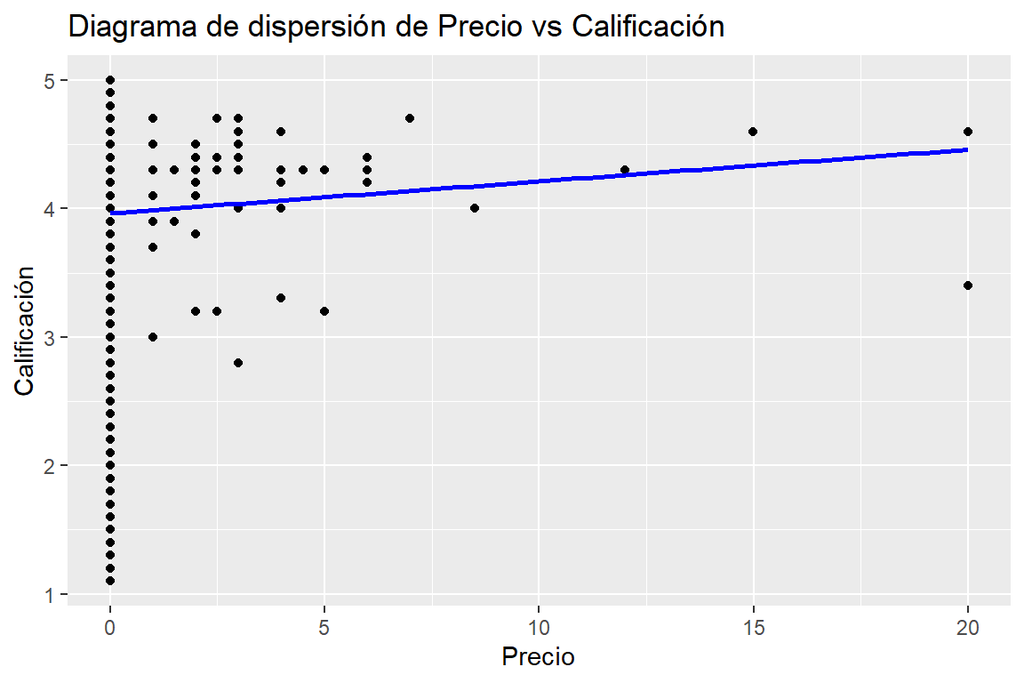

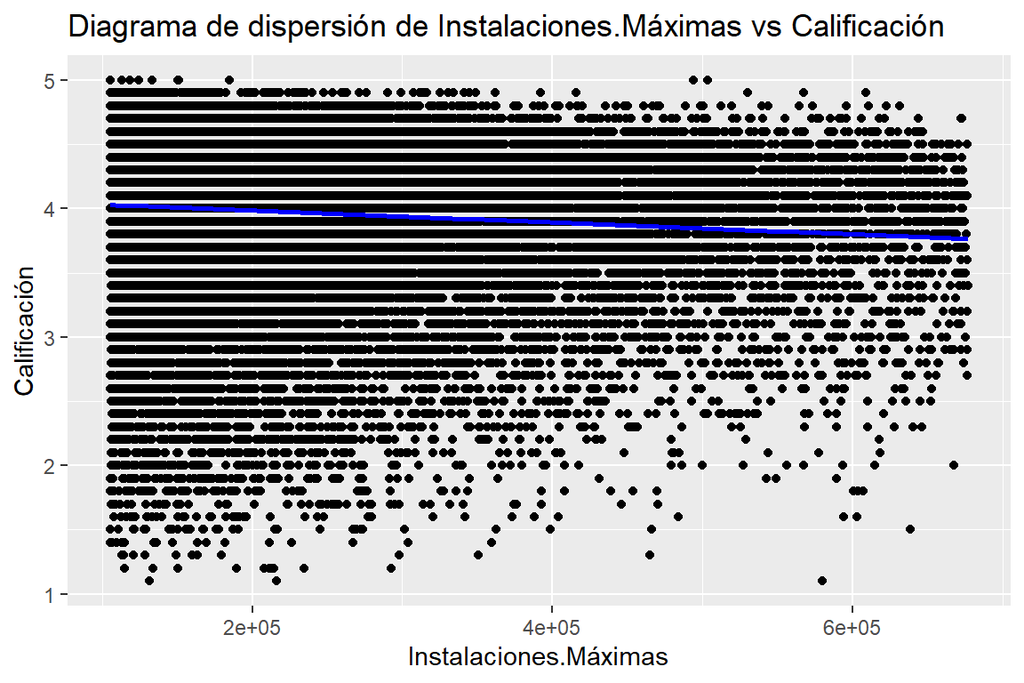

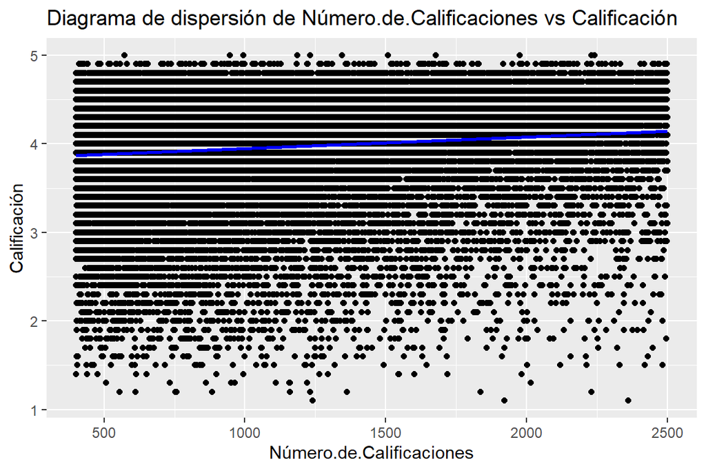

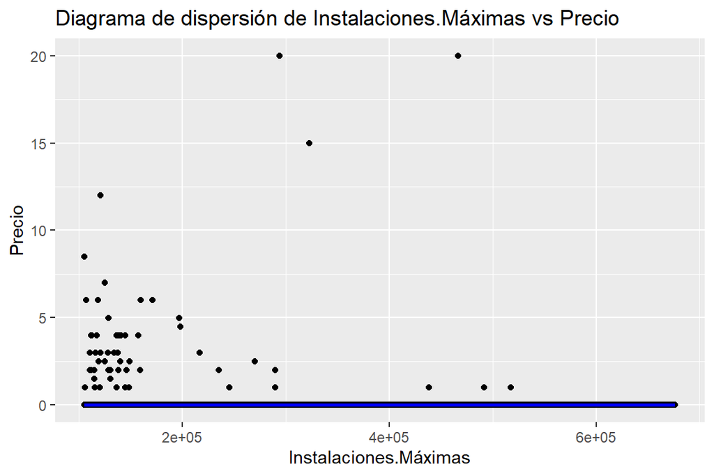

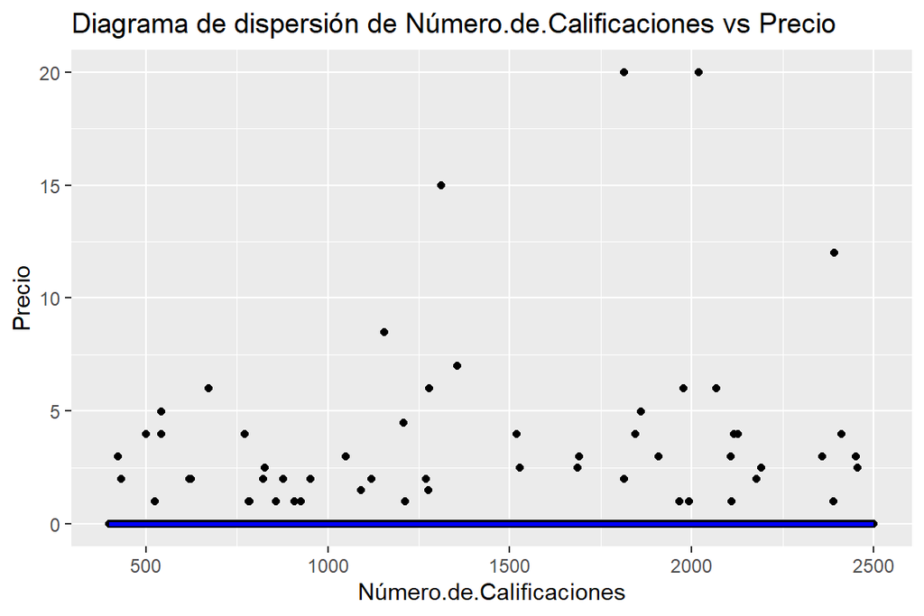

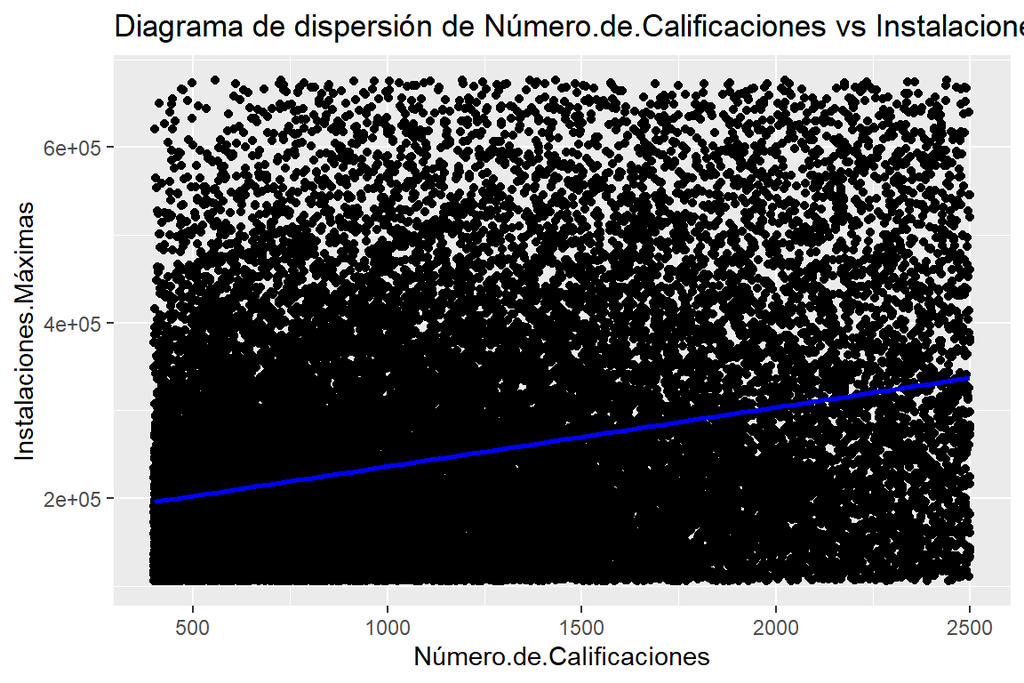

```r
# Gráfico de dispersión
# Crear una lista de todas las combinaciones posibles de variables
combinations <- combn(names(numeric_df), 2)

# Crear un gráfico de dispersión para cada par de variables
for (i in 1:ncol(combinations)) {
  var1 <- combinations[1, i]
  var2 <- combinations[2, i]

  # Crear el gráfico de dispersión
  gg <- ggplot(numeric_df, aes(x = !!sym(var2), y = !!sym(var1))) +
    geom_point() +
    geom_smooth(method = "lm", se = FALSE, color = "blue") +  # Agregar línea de regresión lineal
    labs(title = paste("Diagrama de dispersión de", var2, "vs", var1))

  # Mostrar el gráfico
  print(gg)
}
```

## 4.6 Gráficos multivariables

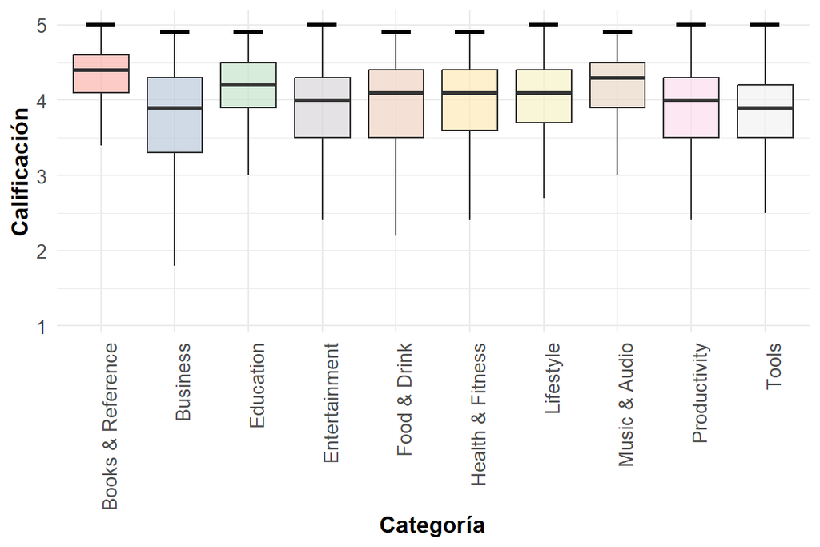

```r
# función para crear el boxplot
crear_boxplot <- function(data, columna_x, columna_y) {
  # Creamos el gráfico base
  plot <- ggplot(data, aes(x = !!sym(columna_x), y = !!sym(columna_y), fill = !!sym(columna_x))) +
    geom_boxplot(outlier.shape = NA, alpha = 0.7) +
    stat_summary(fun = function(x) quantile(x, 0.75), geom = "errorbar", width = 0.4, color = "black", fun.max = max, linewidth = 1.2) +
    labs(x = columna_x, y = columna_y) +
    scale_fill_manual(values = colorRampPalette(brewer.pal(9, "Pastel1"))(length(unique(data[[columna_x]])))) +
    theme_minimal() +
    theme(
      axis.text.x = element_text(angle = 90, vjust = 1, hjust = 1, size = 10),
      axis.text.y = element_text(size = 10),
      axis.title = element_text(size = 12, face = "bold"),
      legend.position = "none"
    )

  return(plot)
}
# Categoria y Calificación
grafico <- crear_boxplot(data = df, columna_x = "Categoría", columna_y = "Calificación")
print(grafico)
```

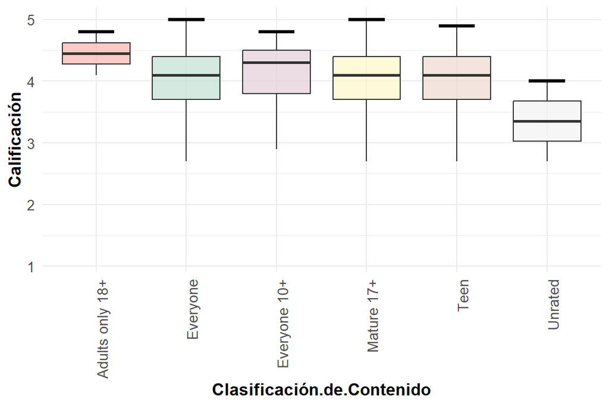

```r
# Clasificación.de.Contenido y Calificación
grafico <- crear_boxplot(data = df, columna_x = "Clasificación.de.Contenido", columna_y = "Calificación")
print(grafico)
```

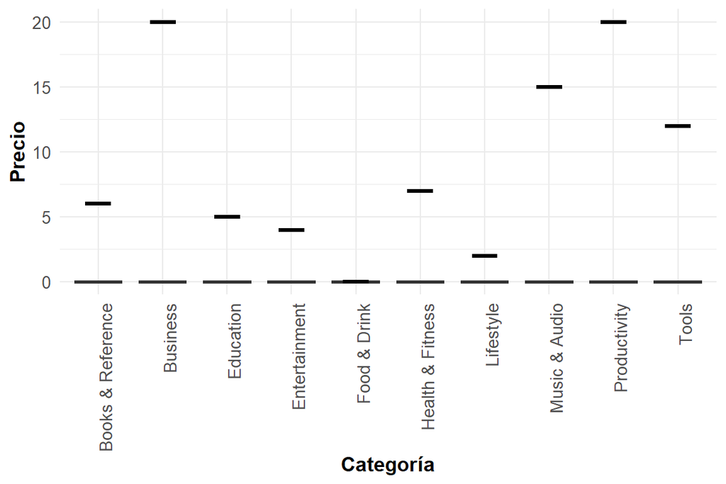

```r
# Categoria y Precio
grafico <- crear_boxplot(data = df, columna_x = "Categoría", columna_y = "Precio")
print(grafico)
```

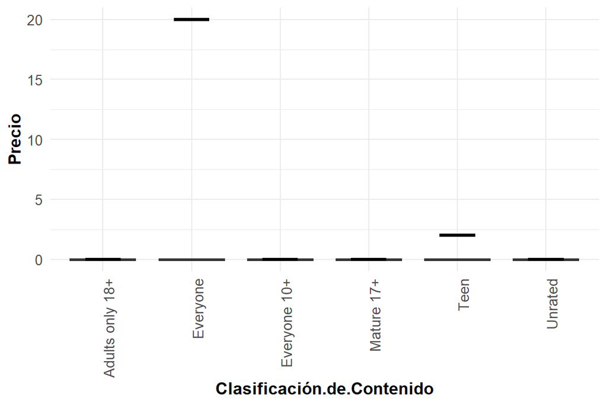

```r
# Clasificación.de.Contenido y Precio
grafico <- crear_boxplot(data = df, columna_x = "Clasificación.de.Contenido", columna_y = "Precio")
print(grafico)
```

# 5 Modelado de Datos

## 5.1 Modelo de Random Forest

```r
# Seleccionar variables de interés
df_selected <- df[, c("Calificación", "Categoría", "Clasificación.de.Contenido", "Admite.Anuncios")]

# Verificar y manejar valores faltantes si los hay
sum(is.na(df_selected))  # Verificar valores faltantes
```

```
## [1] 0
```

```r
df_selected <- na.omit(df_selected)  # Eliminar filas con valores faltantes, si es necesario

# Convertir variables categóricas a factores si es necesario
df_selected$Categoría <- as.factor(df_selected$Categoría)
df_selected$Clasificación.de.Contenido <- as.factor(df_selected$Clasificación.de.Contenido)
df_selected$Admite.Anuncios <- as.factor(df_selected$Admite.Anuncios)

# Entrenar el modelo de Random Forest
rf_model <- randomForest(Calificación ~ Categoría + Clasificación.de.Contenido + Admite.Anuncios, data = df_selected)

# Ver resumen del modelo
print(rf_model)
```

```
##
## Call:
##  randomForest(formula = Calificación ~ Categoría + Clasificación.de.Contenido +      Admite.Anuncios, data = df_selected)
##                Type of random forest: regression
##                      Number of trees: 500
## No. of variables tried at each split: 1
##
##           Mean of squared residuals: 0.3382798
##                     % Var explained: 12.12
```

```r
# Obtener la importancia de las variables
importancia_variables <- importance(rf_model)

# Imprimir los valores de importancia
print(importancia_variables)
```

```
##                            IncNodePurity
## Categoría                      596.72817
## Clasificación.de.Contenido      15.33723
## Admite.Anuncios                629.10896
```

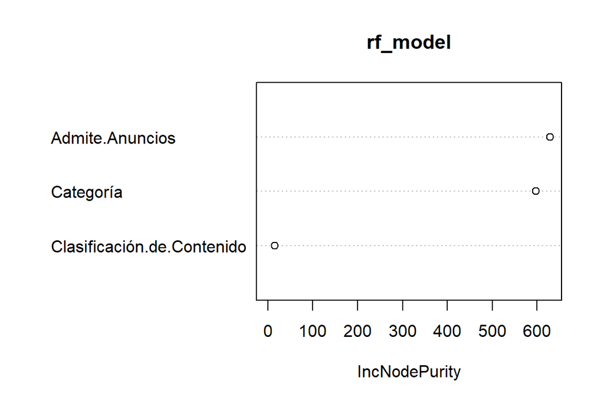

```r
# Ver importancia de las variables
varImpPlot(rf_model)
```

```r
library(rpart)
```

```r
library(rpart.plot)
# Ajustar el modelo de árbol de decisión
tree_model <- rpart(Calificación ~ Categoría + Clasificación.de.Contenido + Admite.Anuncios, data = df_selected)

# Imprimir detalles del árbol
printcp(tree_model)
```

```
##
## Regression tree:
## rpart(formula = Calificación ~ Categoría + Clasificación.de.Contenido +
##     Admite.Anuncios, data = df_selected)
##
## Variables actually used in tree construction:
## [1] Admite.Anuncios Categoría
##
## Root node error: 12070/31357 = 0.38494
##
## n= 31357
##
##         CP nsplit rel error  xerror      xstd
## 1 0.063638      0   1.00000 1.00005 0.0109078
## 2 0.040884      1   0.93636 0.93650 0.0098821
## 3 0.015058      2   0.89548 0.89614 0.0096649
## 4 0.010000      3   0.88042 0.88193 0.0095835
```

```r
summary(tree_model)
```

```
## Call:
## rpart(formula = Calificación ~ Categoría + Clasificación.de.Contenido +
##     Admite.Anuncios, data = df_selected)
##   n= 31357
##
##           CP nsplit rel error    xerror        xstd
## 1 0.06363752      0 1.0000000 1.0000460 0.010907751
## 2 0.04088407      1 0.9363625 0.9365031 0.009882126
## 3 0.01505812      2 0.8954784 0.8961442 0.009664879
## 4 0.01000000      3 0.8804203 0.8819289 0.009583530
##
## Variable importance
## Admite.Anuncios       Categoría
##              51              49
##
## Node number 1: 31357 observations,    complexity param=0.06363752
##   mean=3.965102, MSE=0.3849367
##   left son=2 (9127 obs) right son=3 (22230 obs)
##   Primary splits:
##       Admite.Anuncios            splits as  LR,         improve=0.0636375200, (0 missing)
##       Categoría                  splits as  RLRLLLLRLL, improve=0.0597264300, (0 missing)
##       Clasificación.de.Contenido splits as  RLRLLL,     improve=0.0004429109, (0 missing)
##   Surrogate splits:
##       Categoría splits as  RLRRRRRRRR, agree=0.732, adj=0.081, (0 split)
##
## Node number 2: 9127 observations,    complexity param=0.01505812
##   mean=3.720839, MSE=0.568469
##   left son=4 (8504 obs) right son=5 (623 obs)
##   Primary splits:
##       Categoría                  splits as  RLLLLLLLLL, improve=0.0350315900, (0 missing)
##       Clasificación.de.Contenido splits as  -LRLL-,     improve=0.0004594666, (0 missing)
##
## Node number 3: 22230 observations,    complexity param=0.04088407
##   mean=4.065389, MSE=0.2750297
##   left son=6 (9737 obs) right son=7 (12493 obs)
##   Primary splits:
##       Categoría                  splits as  RLRLRRRRLL, improve=0.0807158700, (0 missing)
##       Clasificación.de.Contenido splits as  RRRLLL,     improve=0.0009366401, (0 missing)
##   Surrogate splits:
##       Clasificación.de.Contenido splits as  RRRLRR, agree=0.565, adj=0.007, (0 split)
##
## Node number 4: 8504 observations
##   mean=3.682643, MSE=0.5592237
##
## Node number 5: 623 observations
##   mean=4.242215, MSE=0.4029209
##
## Node number 6: 9737 observations
##   mean=3.896621, MSE=0.3082817
##
## Node number 7: 12493 observations
##   mean=4.196926, MSE=0.2096119
```

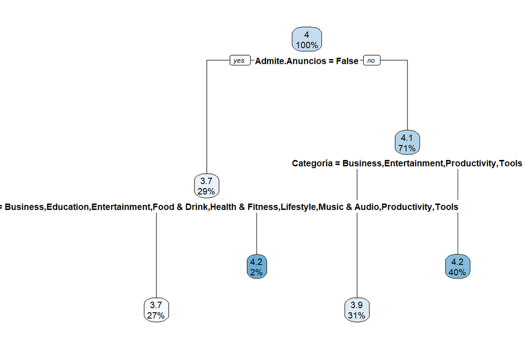

```r
# Graficar el árbol de decisión
rpart.plot(tree_model)
```

# 6 Interpretación de Resultados

## 6.1 Distribuciones y Estadísticas Descriptivas:

Las variables como “Instalaciones Máximas” y “Número de Calificaciones” mostraron amplias variaciones, indicando diferentes niveles de popularidad entre las aplicaciones.

## 6.2 Correlaciones entre Variables:

La matriz de correlación sugiere que las variables numéricas analizadas tienen correlaciones débiles entre sí, lo que implica que cada variable aporta información única al modelo.

## 6.4 Modelado Predictivo

### 6.4.1 Modelo de Random Forest:

Se construyó un modelo de Random Forest para predecir las calificaciones de las aplicaciones.

# 7 Conclusión

La experiencia inicial con R revela un viaje enriquecedor y transformador en el análisis de datos. Este lenguaje no solo simplifica la manipulación y análisis de datos complejos, sino que también abre las puertas a un vasto conjunto de herramientas y técnicas estadísticas. Las librerías desarrolladas por la comunidad activa y colaborativa que respalda R, ofrecen un entorno ideal para el crecimiento continuo en habilidades analíticas y de programación. La amplia disponibilidad de librerías y su naturaleza de código abierto hacen de R una elección poderosa y motivadora para cualquiera interesado en explorar y comprender el mundo a través de los datos.

# 8 Código

Se adjunta el código completo como un archivo .rmd, sin embargo el código se detalla paso a paso en el archivo .html adjunto.